# Fakultät für Physik

#### Auswertung

Zuerst werden die $\mathrm{FWHM}$ der jeweiligen Präparate bestimmt.

```python
def FWHM_finder(sigma):
    return 2*np.sqrt(2*np.log(2))*sigma

na_peak_1_FWHM= FWHM_finder(19.59)
na_peak_2_FWHM= FWHM_finder(31.4)
co_peak_1_FWHM= FWHM_finder(28.36)
co_peak_2_FWHM= FWHM_finder(33.24)
cs_peak_FWHM= FWHM_finder(23.4)
```

```python
# Definieren der Modellfunktion
def aufloesung(E_gamma, A, B, C):
    return A/np.sqrt(E_gamma)+B/E_gamma+C
    #return A/E_gamma



# Energie des Photons und die Energieauflösung
e_gamma= np.array([511,1275,1172,1333,661.7])
FWHM= np.array([na_peak_1_FWHM,na_peak_2_FWHM,co_peak_1_FWHM,co_peak_2_FWHM,cs_peak_FWHM])
```

$\displaystyle \text{Für die Energiekalebrirung ergeben sich folgende Parameter: } A=\left(4.588\pm18.4697\right)\,,\,B=\left(-35.3871\pm259.8121\right)\,,\,C=\left(-0.04299\pm0.3162\right)$

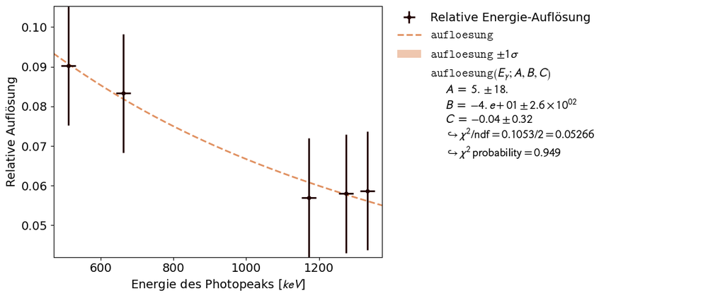

```python
e_dataset = kafe2.XYContainer(x_data=e_gamma,y_data= FWHM/e_gamma)
e_dataset.axis_labels=['Energie des Photopeaks [$keV$]', 'Relative Auflösung']
e_dataset.label='Relative Energie-Auflösung'

e_dataset.add_error(axis='x',err_val=20)
e_dataset.add_error(axis='y',err_val=0.015)

# Fit-Objekt erstellen
fit = kafe2.Fit(e_dataset, aufloesung)

# Fit durchführen
fit.do_fit()
fit.limit_parameter("B", lower=0)
fit.limit_parameter("A", lower=0)

fit_result=kafe2.Plot([fit])

params = fit.parameter_values
param_errors = fit.parameter_errors
A = params[0]

# Ergebnisse ausgeben
display(Math(rf'\text{{Für die Energiekalebrirung ergeben sich folgende Parameter: }} A=\left({params[0]:.04}\pm{param_errors[0]:.4f}\right)\,,\,B=\left({params[1]:.4f}\pm{param_errors[1]:.4f}\right)\,,\,C=\left({params[2]:.04}\pm{param_errors[2]:.4f}\right)'))

# Fit-Ergebnisse plotten
fit_result.plot()
plt.show()
```

Unter der Annahme, dass eine verhältnismäßig große Unsicherheit bei der bestimmten relativen Auflösung auftretet ist ein Fit mit hoher Wahrlscheinlichkeit zu finden.  
Anhand der gefundenen Parametern wird ersichtlich, dass der teil $\frac A{\sqrt{E_\gamma}}$ den Verlauf am stärksten beinflüsst und der Parameter $B$ obwohl es verhältnismäßig viel größer ist von viel weniger bedeutung ist.

Um nun mithilfe des aus dem Fit erhaltene $A$ die Anzahl $\mu_{N_e}$ wie folgt bestimmen:

$$ \mu_{N_e}=\left(\frac{\mu_Q}{\sigma_Q}\right)^2 $$

Wobei $\mu_Q$ der Erwartungswert der Energie ist und $\sigma_Q$ derren Standardabweichung.
In diesem Fall folgt dann: $$ N_e = \left(\frac{E_\gamma}{\Delta E_\gamma}\right)^2 $$

Mithilfe der Näherung: $$ \sqrt{\frac{A^2}{E_\gamma}+\frac{b^2}{E_\gamma^2}+C^2}\sim A $$ kommt die lässt sich die Formel für $N_e$ zu $$ N_e = \frac{E_\gamma}{A^2} $$ umschreiben.

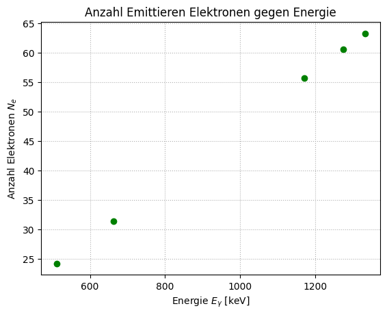

```python
mu_ne = e_gamma/(A**2)

plt.scatter(e_gamma, mu_ne, color = 'green')
plt.title('Anzahl Emittieren Elektronen gegen Energie')
plt.xlabel(r'Energie $E_\gamma$ [keV]')
plt.ylabel(r'Anzahl Elektronen $N_e$')
plt.grid(linestyle='dotted')
plt.show()
```

Es wird nun noch einen Fit angelegt um eine Gerade zu bestimmen, mitder man für beliebige Energien nun die Anzahl an Photonen bestimmen kann.

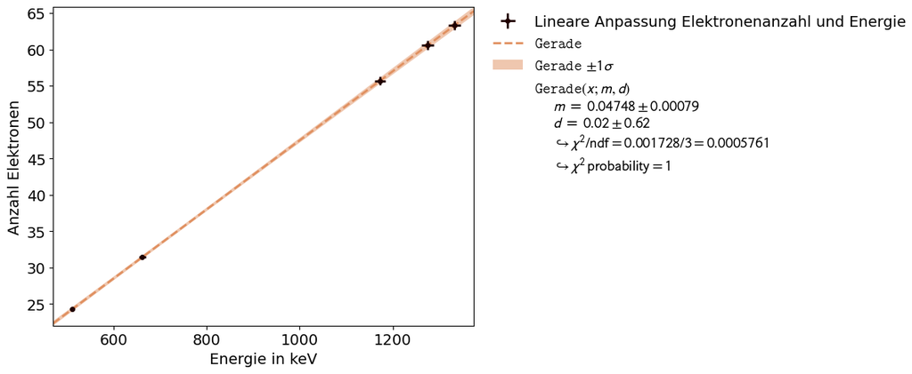

```python
def Gerade(x, m, d):
 return m*x + d


xy_gerade2 = kafe2.XYContainer(x_data= e_gamma , y_data= mu_ne)
xy_gerade2.label = 'Lineare Anpassung Elektronenanzahl und Energie'
fit = kafe2.XYFit(xy_data = xy_gerade2, model_function = Gerade)
fit.add_error(axis='x', err_val=0.01*e_gamma)
fit.add_error(axis='y', err_val=0.01*mu_ne)
fit.do_fit()
plot = kafe2.Plot(fit)
plot.x_label = "Energie in keV"
plot.y_label = "Anzahl Elektronen"
plot.plot()
plot.show()
m = fit.parameter_values[0]
d = fit.parameter_values[1]
```

Anhand des Diagramms ist zu erkennen, dass die Anzahl an ankommende Elektronen erschtaunlich gering ist und somit einen Photonenmultipier sehr nützlich ist.

## Aufgabe 3: Detektorakzeptanz

**Hinweise zu Aufgabe 3 finden in der Datei Hinweise-Versuchsdurchfuehrung.md.**

- Bestimmen Sie Rate aufgezeichneter Photonen für $_{\hphantom{0}55}^{137}\mathrm{Cs}$ bei fünf verschiedenen Abständen des Präparats von der Detektorstirnfläche.
- Schätzen Sie ab und begründen Sie, ob eine Korrektur auf den unterliegenden Untergrund notwendig ist.
- Schätzen Sie ab und begründen Sie, ob eine Korrektur des Detektors auf pile-up notwendig ist.
- Fügen Sie eine Darstellung der bestimmten Messpunkte ins Protokoll ein und passen Sie ein entsprechendes Modell daran an.

**Lösung:**

#### Vorbereitung

Bei diesen Messungen ist der Abzug des Untergrundes von noch größerer Bedeutung.  
Bei zunehmneder Entfernung wird die durchschnittliche Anzahl der ankommenden Photonen sinken, da $A\sim \frac1{d^2}$; hierbei handelt es sich sogar um eine quadratische Abhängigkeit! Dementsprechend wird bei großen Abständen der Untergrund die Messwerte dominieren und so treten Verfälschungen der Messwerte auf.

Dagegen sind gegen Pile-up keine Vorkehrungen notwendig, da wie zuvor erwähnt, die zeitliche Auflösung des Detektors gut genug ist, dass dieser Effekt verschwindend gering Auftreten könnte.

#### Versuchsdurchführung

Das Präparat wird anfangs bei einem Abstand von $\sim 0\mathrm{mm}$ zum Detektor Deckel angebracht und es wird über eine Zeit von $t = 1\mathrm{min}$ danach wird diese sukzessive auf $\sim 10\mathrm{mm}$, $\sim 40\mathrm{mm}$, $\sim 90\mathrm{mm}$, $\sim 160\mathrm{mm}$ erhöht. Die Messdauer bleibt hier stehts gleich.

Dabei enstehen dann die folgende Abbildungen:

[figure not shown]

**Abbildung 3.1:** Messung bei dem Abstand $0 \mathrm{mm}$

[figure not shown]

**Abbildung 3.2:** Messung bei dem Abstand $10\mathrm{mm}$

[figure not shown]

**Abbildung 3.3:** Messung bei dem Abstand $40\mathrm{mm}$

[figure not shown]

**Abbildung 3.4:** Messung bei dem Abstand $90 \mathrm{mm}$

[figure not shown]

**Abbildung 3.5:** Messung bei dem Abstand $160 \mathrm{mm}$

#### Auswertung

Bereits an den Rohen Messwerten kann man bereits sehen, dass die Form des Spektrums beibehalten wird. Dies liegt daran, dass lediglich die Rate an ankommende Photonen abnimmt.  
Außerdem ist ein intensives Rauchen bei größere Abstände (wie etwa bei dem Abstand von $160\mathrm{mm}$) zu erkennen. Beim Vergleichen der Raten mit dennen des Untergrundes wird der Grund ersichtlich. Es liegt daran, dass die beiden Raten in einem sehr vergleichbarem bereich sind.

Der vollstaändigkeitshalber werden aber davor noch die Messreiehn ohne dem Untergrund noch schnell gezeigt.

##### Abstand $0\mathrm{mm}$

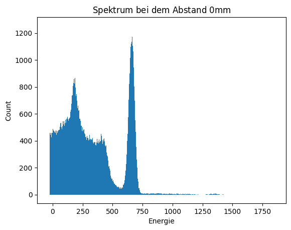

```python
h0_peak = np.genfromtxt("./Messungen/Casium_Weird-Heights/Höhe_0.hst")
h0_channel = np.arange(len(h0_peak))

plt.bar(channel_to_energie(h0_channel), h0_peak-(normierte_zaehlraten*1), width = 1)
plt.title(rf'Spektrum bei dem Abstand $0\mathrm{{mm}}$')
plt.xlabel('Energie')
plt.ylabel('Count')

plt.show()
```

##### Abstand $10\mathrm{mm}$

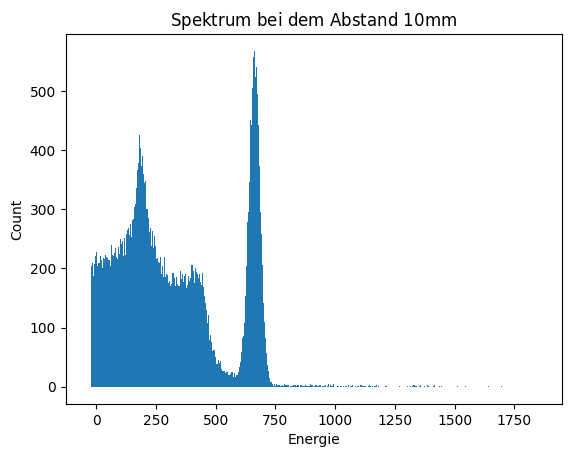

```python
h10_peak = np.genfromtxt("./Messungen/Casium_Weird-Heights/Höhe_10.hst")
h10_channel = np.arange(len(h10_peak))

plt.bar(channel_to_energie(h10_channel), h10_peak-(normierte_zaehlraten*1), width = 1)
plt.title(rf'Spektrum bei dem Abstand $10\mathrm{{mm}}$')
plt.xlabel('Energie')
plt.ylabel('Count')

plt.show()
```

##### Abstand $40\mathrm{mm}$

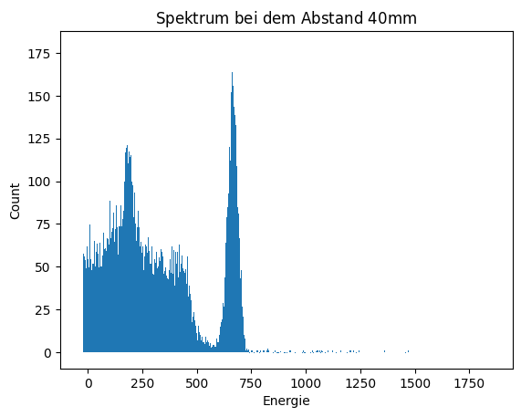

```python
h40_peak = np.genfromtxt("./Messungen/Casium_Weird-Heights/Höhe_40.hst")
h40_channel = np.arange(len(h40_peak))

plt.bar(channel_to_energie(h40_channel), h40_peak-(normierte_zaehlraten*1), width = 1)
plt.title(rf'Spektrum bei dem Abstand $40\mathrm{{mm}}$')
plt.xlabel('Energie')
plt.ylabel('Count')

plt.show()
```

##### Abstand $90\mathrm{mm}$

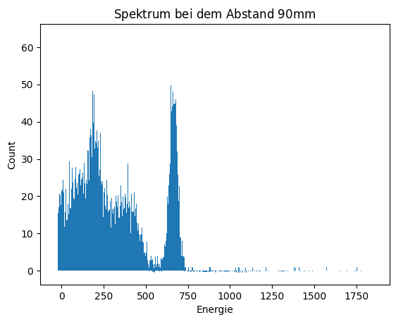

```python
h90_peak = np.genfromtxt("./Messungen/Casium_Weird-Heights/Höhe_90.hst")
h90_channel = np.arange(len(h90_peak))

plt.bar(channel_to_energie(h90_channel), h90_peak-(normierte_zaehlraten*1), width = 1)
plt.title(rf'Spektrum bei dem Abstand $90\mathrm{{mm}}$')
plt.xlabel('Energie')
plt.ylabel('Count')

plt.show()
```

##### Abstand $160\mathrm{mm}$

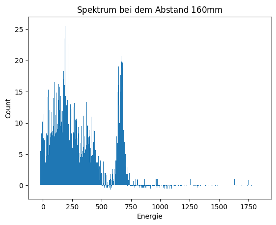

```python
h160_peak = np.genfromtxt("./Messungen/Casium_Weird-Heights/Höhe_160.hst")
h160_channel = np.arange(len(h160_peak))

plt.bar(channel_to_energie(h160_channel), h160_peak-(normierte_zaehlraten*1), width = 1)
plt.title(rf'Spektrum bei dem Abstand $160\mathrm{{mm}}$')
plt.xlabel('Energie')
plt.ylabel('Count')

plt.show()
```

##### Auftragen der Raten

Wie in der Vorbereitung vermutet, haben sich die Lagen der einzelnen Struckturen lediglich die Raten.

Es wird nun die Summe der Messwerte gemacht und diese für einen Fit unterzogen. An dieser Stelle ist wichtig zu erwähnen, dass es einen Offset zwischen dem tatsächlichen Detektor und die Strahlungsquelle. Im Model wird dies als $"b"$ bezeichnet. Zudem wird die Bedingung, dass der Off-set nicht $< 0$ sein darf.

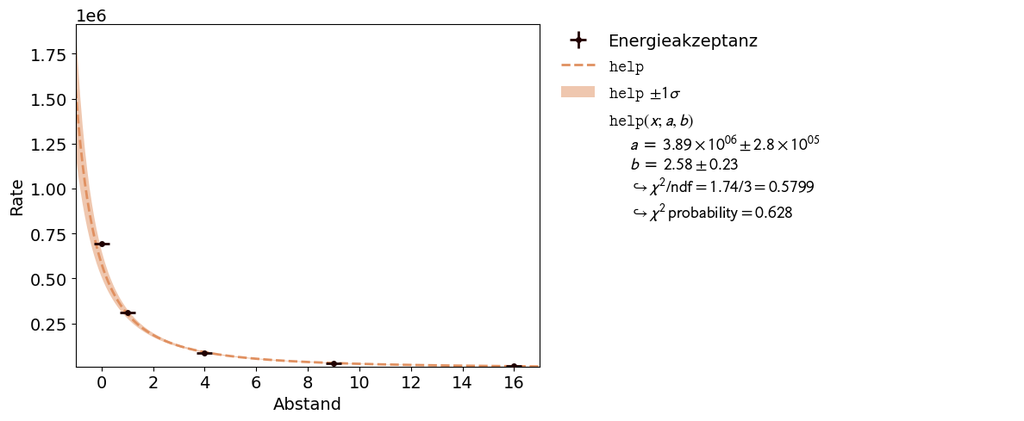

```python
# Daten für Kanalnummern und entsprechende Energien
Abstand = np.array([0, 1, 4,9,16]) # in cm
Rate = np.array([np.sum([h0_peak]),np.sum([h10_peak]), np.sum([h40_peak]),np.sum([h90_peak]),np.sum([h160_peak])])


# Fit-Funktion definieren
def help(x, a, b):
    return a/((x+b)**2)

# Dataset erstellen
dataset = kafe2.XYContainer(x_data=Abstand,y_data=Rate)
dataset.axis_labels=['Abstand', 'Rate']
dataset.label='Energieakzeptanz'

dataset.add_error(axis='x',err_val=0.3)
dataset.add_error(axis='y',err_val=1E3)



# Fit-Objekt erstellen
fit = kafe2.Fit(dataset, help)
fit.limit_parameter("b", lower=0)

# Fit durchführen
fit.do_fit()
fit_result=kafe2.Plot([fit])


# Fit-Ergebnisse plotten
# fit_result.y_range=(0,2000)
fit_result.x_range=(-1,17)
fit_result.plot()
plt.show()
```

Wie in der Vorbereitung bereits besprochen, besteht eine $\sim\frac 1{d^2}$ Abhängigkeit zur Rate. Dies wird auch im Fit erkenntlich.  
Außerdem ist ersichtlich, dass sich die Abweichung der Werte bei kleinere Abstände eine größere Streuung aufweißen. Usrache dafür könnte die größe Anzahl an aufgezeichnete Photonen, welche Comptonstreuungen durchführen.